# Summarize model performance of MIEML trained models

Joseph Bundy

3/11/2025

This notebook is used to extract model summary information from MIEML result files

## Data Import

First import MIEML functions

```r
source("../scripts/ML_functions_HTTr.R")
```

use summarize_results_from_files to build a result summary dataframe for each model

```r
  results <- summarize_results_from_files(analysis_folder = "../data/model_files/analysis_3_8_2025")
```

```
reading from mie folder 1 of 9
reading from mie folder 2 of 9
reading from mie folder 3 of 9
reading from mie folder 4 of 9
reading from mie folder 5 of 9
reading from mie folder 6 of 9
reading from mie folder 7 of 9
reading from mie folder 8 of 9
reading from mie folder 9 of 9
```

## Explore Model Performance

Create simple plot of internal accuracy as a function of training algorithm

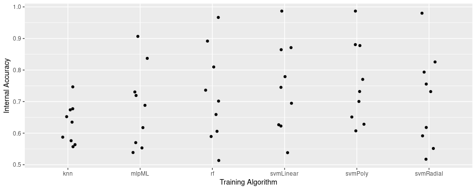

```r
library(ggplot2)
ggplot(data = results, aes(x=as.factor(model_name), y=internal_accuracy)) +
      #geom_boxplot() +
  geom_jitter(width = 0.1) +
      xlab("Training Algorithm") +
  ylab("Internal Accuracy") +
      theme(legend.position="none")
```

Create a “passed_EST” column to annotate models as either passing or failing empirical significance testing based on internal and holdout accuracies

```r
results$passed_EST <- "no"
results[results$int_acc_emp_pval <= 0.1 & results$hold_acc_emp_pval <= 0.1,]$passed_EST <- "yes"
```

how many classifiers passed empirical significance testing?

```r
nrow(results[results$passed_EST == "yes",])
```

```
[1] 15
```

what is the median internal accuracy of HPCs?

```r
median(results[results$passed_EST == "yes",]$internal_accuracy)
```

```
[1] 0.8774194
```

```r
median(results[results$passed_EST == "yes",]$holdout_accuracy)
```

```
[1] 0.8888889
```

what molecular targets are represented among HPCs

```r
unique(results[results$passed_EST == "yes",]$target_name)
```

```
[1] "AHR_Positive"        "ESR1_Positive_group" "NR3C1_Positive"
```

use the “make_annotations_pretty” function to reformat molecular target annotations to be more human readable

```r
results$pretty_MIE_name <- make_annotations_pretty(results$target_name)
unique(results[results$passed_EST == "yes",]$pretty_MIE_name)
```

```
[1] "AHR Agonism"   "ESR1 Agonism"  "NR3C1 Agonism"
```

write classifier performance summary to disk

```r
write.csv(results, file = "../data/classifier_performance_summary.csv")
```

what MIEs had the highest and lowest internal accuracies on average?

```r
library(data.table)
temp_by_MIE_performance <- data.table(results)
temp_by_MIE_performance <-  temp_by_MIE_performance[,.(by_MIE_mean=mean(internal_accuracy),
                                                  by_MIE_sd=sd(internal_accuracy)),by=pretty_MIE_name]
temp_by_MIE_performance
```

| pretty_MIE_name | by_MIE_mean | by_MIE_sd |
| --- | --- | --- |
| ACHE Antagonism | 0.7409314 | 0.03786660 |
| AHR Agonism | 0.9288889 | 0.09424947 |
| AR Antagonism | 0.5784274 | 0.03475657 |
| CA2 Antagonism | 0.5845658 | 0.04239819 |
| ESR1 Agonism | 0.7913978 | 0.08031330 |
| NR1I2 Agonism | 0.5804040 | 0.05498265 |
| NR3C1 Agonism | 0.8252753 | 0.08837488 |
| PPARG Agonism | 0.6905338 | 0.06008141 |
| PTGS2 Antagonism | 0.6513957 | 0.05422584 |

what algorithm had the highest and lowest internal accuracies on average?

```r
library(data.table)
temp_by_MIE_performance <- data.table(results)
temp_by_MIE_performance <-  temp_by_MIE_performance[,.(by_algorithm_mean=mean(internal_accuracy),
                                                  by_algorithm_sd=sd(internal_accuracy)),by=model_name]
temp_by_MIE_performance
```

| model_name | by_algorithm_mean | by_algorithm_sd |
| --- | --- | --- |
| knn | 0.6299029 | 0.0640040 |
| mlpML | 0.6845764 | 0.1284552 |
| rf | 0.7192374 | 0.1481067 |
| svmLinear | 0.7476038 | 0.1431364 |
| svmPoly | 0.7593595 | 0.1307129 |
| svmRadial | 0.7072003 | 0.1502071 |

Define useful functions for plotting

```r
`%notin%` <- Negate(`%in%`)

gg_color_hue <- function(n) {
  hues = seq(15, 375, length = n + 1)
  hcl(h = hues, l = 65, c = 100)[1:n]
}
```

Generate barplot showing % of null classifiers out competed by standard classifier

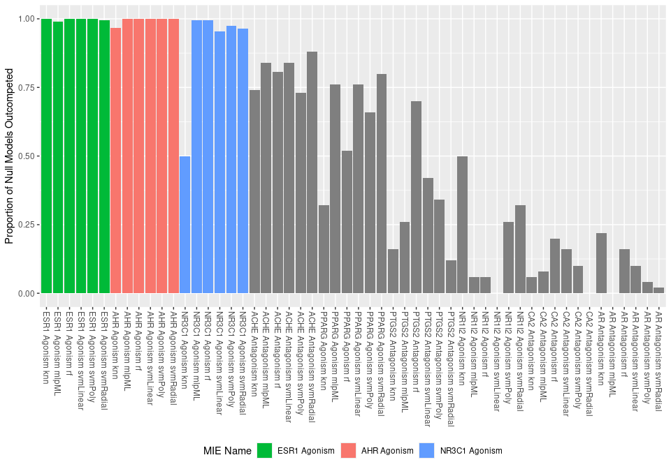

```r
library(ggrepel)
fills = c("AHR Agonism" = gg_color_hue(3)[1],
          "ESR1 Agonism" = gg_color_hue(3)[2],
          "NR3C1 Agonism" = gg_color_hue(3)[3],
          "Other" = "black")

temp_results <- results
temp_results$prop_null_outcompeted <- 1 - temp_results$int_acc_emp_pval

temp_table <- data.table(temp_results)
temp_table <- temp_table[,.(mean=mean(prop_null_outcompeted)),by=pretty_MIE_name]
temp_table <- temp_table[order(temp_table$mean, decreasing = TRUE),]

temp_results$pretty_MIE_name <- factor(temp_results$pretty_MIE_name, levels = temp_table$pretty_MIE_name)

temp_results$compound_name <- paste0(temp_results$pretty_MIE_name, " ", temp_results$model_name)

temp_results <- temp_results[order(sapply(temp_results$pretty_MIE_name, function(x) which(x == temp_table$pretty_MIE_name))), ]

temp_results$compound_name <- factor(temp_results$compound_name, levels = temp_results$compound_name)

ggplot(data = temp_results, aes(y= prop_null_outcompeted, x = compound_name, fill = pretty_MIE_name)) +
      geom_bar(stat = "identity") +
  ylab("Proportion of Null Models Outcompeted") +
  scale_fill_manual(values = fills) +
      theme(axis.title.x = element_blank(),
            axis.text.x = element_text(angle = -90, vjust = .5, hjust=-.0)) +
     guides(color = guide_legend(title="MIE Name", ncol = 2),
            fill=guide_legend(title="MIE Name")) +
  theme(legend.position = "bottom",
        legend.box = "vertical")
```

floor signifiance results to 0.001 for plotting

```r
results[results$int_acc_emp_pval <= 0.001,]$int_acc_emp_pval <- 0.001
results[results$hold_acc_emp_pval <= 0.001,]$hold_acc_emp_pval <- 0.001
```

initialize a list object for storing plots for multi-pane plots

```r
plot_list <- list()
```

Plot internal accuracy as a function of molecular target

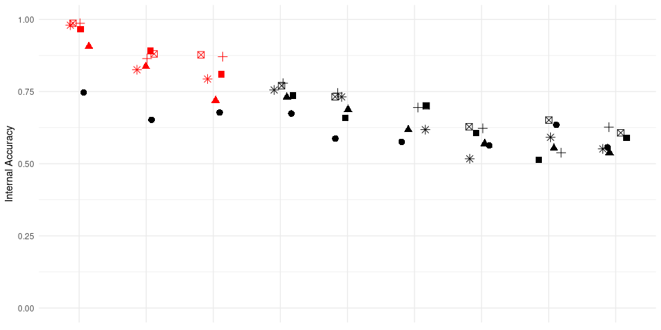

```r
order <- data.table(results)
order <-  order[,.(mean=mean(internal_accuracy)),by=pretty_MIE_name]
order <- data.frame(order)
order <- order[order(order$mean, decreasing = TRUE),]$pretty_MIE_name

results$MIE <- results$pretty_MIE_name
results[results$pretty_MIE_name %notin% c("AHR Agonism", "ESR1 Agonism", "NR3C1 Agonism"),]$MIE <- "Other"

results$pretty_MIE_name <- factor(results$pretty_MIE_name, levels = order)


fills = c("yes" = "red",
          "no" = "black")

plot_list[["internal_accuracy_dotplot"]] <- ggplot(data = results, aes(x=as.factor(pretty_MIE_name),
                                                                       y=internal_accuracy,
                                                                       pch = model_name,
                                                                       color = passed_EST)) +
      geom_jitter(size = 3, width = 0.2) +
  ylim(c(0,1)) +
  ylab("Internal Accuracy") +
  scale_color_manual(values = fills) +
  theme_minimal() +
      theme(axis.title.x = element_blank(),
            axis.text.x = element_blank(),
            legend.position = "none")

plot_list[["internal_accuracy_dotplot"]]
```

Generate a similar plot but with holdout accuracies

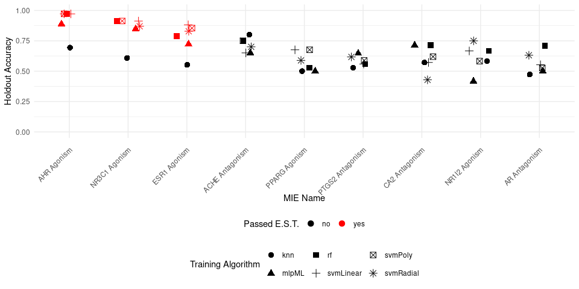

```r
plot_list[["holdout_accuracy_dotplot"]] <- ggplot(data = results, aes(x=as.factor(pretty_MIE_name), y=holdout_accuracy, pch = model_name, color = passed_EST)) +
      geom_jitter(size = 3, width = 0.2) +
      xlab("MIE Name") +
    ylim(c(0,1)) +
    scale_color_manual(values = fills, name = "Passed E.S.T.") +
  ylab("Holdout Accuracy") +
    theme_minimal() +
      theme(axis.text.x = element_text(angle = 45, vjust = 0.9, hjust=1),
            legend.position = "bottom",
            legend.box = "vertical") +
  guides(shape=guide_legend(title="Training Algorithm"))

plot_list[["holdout_accuracy_dotplot"]]
```

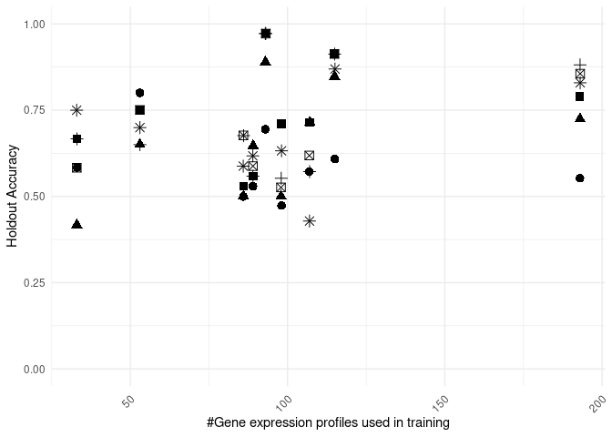

```r
plot_list[["internal_accuracy_by_training_profiles_dotplot"]] <- ggplot(data = results, aes(x=target_members, y=holdout_accuracy, pch = model_name)) +
      geom_jitter(size = 3, width = 0.1) +
      xlab("#Gene expression profiles used in training") +
    ylim(c(0,1)) +
  ylab("Holdout Accuracy") +
    theme_minimal() +
      theme(axis.text.x = element_text(angle = 45, vjust = 0.9, hjust=1),
            legend.position = "none")

plot_list[["internal_accuracy_by_training_profiles_dotplot"]]
```

Generate a scatter plot of empirical and holdout accuracy empirical significance

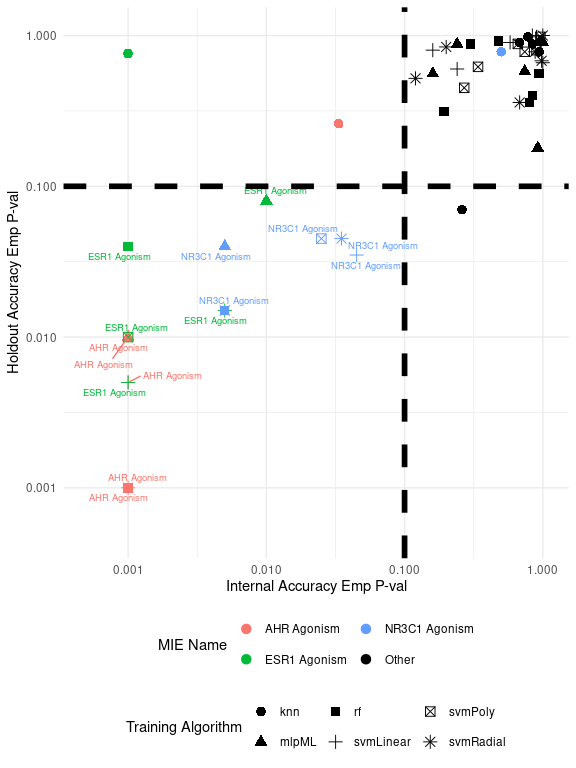

```r
fills = c("AHR Agonism" = gg_color_hue(3)[1],
          "ESR1 Agonism" = gg_color_hue(3)[2],
          "NR3C1 Agonism" = gg_color_hue(3)[3],
          "Other" = "black")

plot_list[["emp_pvalue_regression"]] <- ggplot(data = results, aes(x= int_acc_emp_pval, y= hold_acc_emp_pval, pch = model_name, color = MIE)) +
      geom_point(size = 3) +
  geom_text_repel(data = results[results$int_acc_emp_pval <= 0.1 & results$hold_acc_emp_pval <= 0.1,],
                  aes(x= int_acc_emp_pval,
                      y= hold_acc_emp_pval,
                      label = make_annotations_pretty(target_name)),
                  size = 2.5) +
      xlab("Internal Accuracy Emp P-val") +
  ylab("Holdout Accuracy Emp P-val") +
  scale_color_manual(values = fills) +
  scale_y_continuous(trans='log10', limits = c(0.0005, 1.05)) +
  scale_x_continuous(trans='log10', limits = c(0.0005, 1.05)) +
  # xlim(-0.05, 1.05) +
  # ylim(-0.05, 1.05) +
  geom_vline(xintercept = 0.1, linetype = 2, color = "black", linewidth = 2) +
  geom_hline(yintercept = 0.1, linetype = 2, color = "black", linewidth = 2) +
      #theme(axis.text.x = element_text(angle = 45, vjust = 0.9, hjust=1)) +
     guides(color = guide_legend(title="MIE Name", ncol = 2),
            pch=guide_legend(title="Training Algorithm")) +
    theme_minimal() +
  theme(legend.position = "bottom",
        legend.box = "vertical")

plot_list[["emp_pvalue_regression"]]
```

```r
tiff(filename = "../figures/emp_pvalue_regression.tiff", height = 8, width = 6, units = "in", res = 300)
print(
plot_list[["emp_pvalue_regression"]]
  )
dev.off()
```

Generate histogram showing volume of available training data

```r
collapsed_targets <- collapse_refchemdb_targets(refchemdb_path = "../data/refchemdb/NIHMS1537541-supplement-Supplement1.xlsx",
                                                support_levels = c(3),
                                                min_chemicals = 5,
                                                cutree_h = 0.7,
                                                cluster_method= "complete")
```

```
This will probably take some time...
importing refchem
tabulating targets
calculating jaccard indices
editing chemical manifest
```

```r
target_annotations <- collapsed_targets$collapsed_targets
target_annotations <- target_annotations[target_annotations$support >= 3,]

stingy_target_annotations <- data.frame()
for (i in unique(target_annotations$dsstox_substance_id)){
  relevant_targets <- target_annotations[target_annotations$dsstox_substance_id == i,]
  if(nrow(relevant_targets) > 0){
    relevant_targets <- relevant_targets[order(relevant_targets$support, decreasing = TRUE),]
    stingy_target_annotations <- rbind(head(relevant_targets, 1), stingy_target_annotations)
  }
}
target_annotations <- stingy_target_annotations
rm(stingy_target_annotations)


message("- tabulating preprocessed targets -\n")
```

```
- tabulating preprocessed targets -
```

```r
target_table <- table_targets(target_annotations)

message("- importing HTTr metadata -\n")
```

```
- importing HTTr metadata -
```

```r
metadata <- readRDS("../data/mongodb_dump/httr_metadata.rds")
metadata <- metadata[metadata$dtxsid %in% target_annotations$dsstox_substance_id,]

message("- Selecting Bioactive HTTr metadata -\n")
```

```
- Selecting Bioactive HTTr metadata -
```

```r
tpod_estimates <- read.csv("../data/tpod_estimates/tpod_estimates.csv", header = TRUE)
metadata <- merge(metadata, tpod_estimates[c("chem_id", "gene_bpac05")], by = "chem_id")
metadata <- metadata[metadata$conc > metadata$gene_bpac05,]

message("- importing relevant HTTr expression data -\n")
```

```
- importing relevant HTTr expression data -
```

```r
nested_data <- get_gene_expression_data( metadata = metadata,
                                         gene_expression_data_path = "../data/gene_expression/normalized_gene_expression_data.rds",
                                         seed = 123,
                                         profile_limit = 20)
```

```
- loading gene expression data -

Triming overrepresented chemicals from analysis
```

```r
message("- tabulating available HTTr profiles -\n")
```

```
- tabulating available HTTr profiles -
```

```r
profile_table <- table_profiles(target_table = target_table,
                                metadata = nested_data$metadata,
                                target_annotations = target_annotations,
                                min_chemicals = 5,
                                min_profiles = 25)

message("- identifying top reference chemicals for tabulated targets -\n")
```

```
- identifying top reference chemicals for tabulated targets -
```

```r
exemplar_chems <- get_exemplar_chems(target_annotations = target_annotations,
                                     metadata = nested_data$metadata,
                                     profile_table = profile_table,
                                     min_chemicals = 5,
                                     min_profiles = 25,
                                     target_table = target_table)

#save exemplar chemicals to disk to be used in the subsequent notebook
write.csv(exemplar_chems, file = "../data/exemplar_chems.csv")

message("- re-tabulating HTTr profiles excluding exemplar reference chemicals -\n")
```

```
- re-tabulating HTTr profiles excluding exemplar reference chemicals -
```

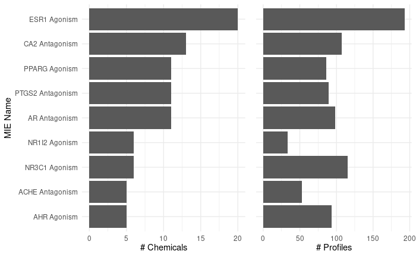

```r
profile_table <- table_profiles(target_table = target_table,
                                metadata = nested_data$metadata,
                                target_annotations = target_annotations,
                                min_chemicals = 5,
                                min_profiles = 25,
                                exemplar_chems = exemplar_chems)


temp <- profile_table

#make MIE names more readable
temp$target_mode <- make_annotations_pretty(temp$target_mode)

temp <- temp[order(temp$n_chemicals, decreasing = FALSE),]
temp$target_mode <- factor(temp$target_mode, levels = temp$target_mode)

names(temp) <- c("MIE Name", "# Profiles", "# Chemicals")

left_plot <- ggplot(temp, aes(x = `MIE Name`,y =  `# Chemicals`)) +
  geom_bar(stat = "identity") +
    theme_minimal() +
  coord_flip()

right_plot <- ggplot(temp, aes(x = `MIE Name`,y =  `# Profiles`)) +
  geom_bar(stat = "identity") +
  coord_flip() +
    theme_minimal() +
  theme(axis.text.y = element_blank(),
        axis.ticks.y =  element_blank(),
        axis.title.y = element_blank())

library(cowplot)
plot_list[["training_data_volume"]] <- plot_grid(left_plot,
          right_plot,
          ncol = 2,
          nrow = 1,
          rel_widths = c(1.5,1),
          align = "h",
          axis = "tblr")

plot_list[["training_data_volume"]]
```

Generate combined figure with training data volume and model performance

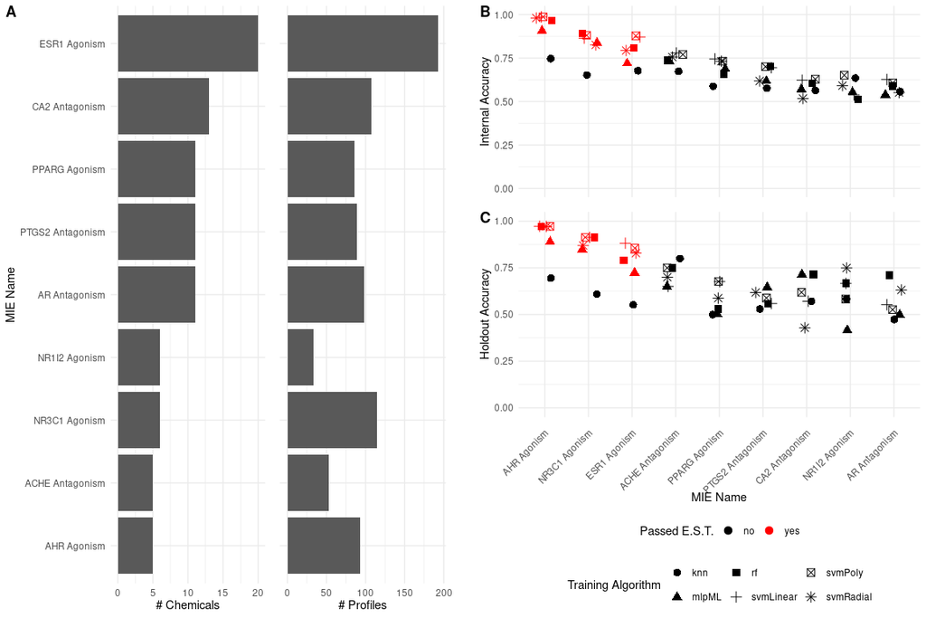

```r
left_plot <-  plot_grid(plot_list[["internal_accuracy_dotplot"]],
                        plot_list[["holdout_accuracy_dotplot"]],
                        ncol = 1,
                        nrow = 2,
                        labels = c("B", "C"),
                        rel_heights = c(1,2)
)

plots <- plot_grid(
  plot_list[["training_data_volume"]],
  NULL,
  left_plot,
  labels = c("A", "", ""),
          ncol = 3,
          nrow = 1,
          rel_widths = c(1,0.05,1)
)

print(
  plot_grid( plots, ncol=1, rel_heights=c(0.1, 1))
  )
```

Save figure to disk

```r
tiff(filename = "../figures/classifier_performance.tiff", height = 8, width = 12, units = "in", res = 300)
print(
  plot_grid(plots, ncol=1, rel_heights=c(0.1, 1))
  )
dev.off()
```

Generate more compact plot of classifier performance and available training data

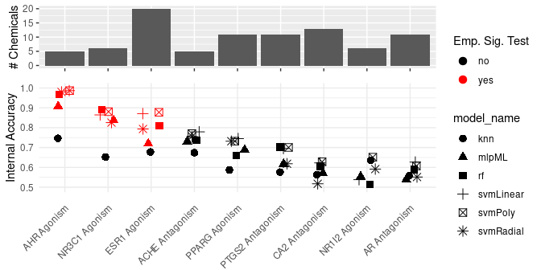

```r
temp$`MIE Name` <- factor(temp$`MIE Name`, levels = levels(results$pretty_MIE_name))

top_plot <- ggplot(temp, aes(x = `MIE Name`,y =  `# Chemicals`)) +
  geom_bar(stat = "identity") +
 theme(axis.text.x = element_blank(),
       axis.title.x = element_blank())

fills = c("yes" = "red",
          "no" = "black")

bottom_plot <- ggplot(data = results, aes(x=as.factor(pretty_MIE_name),
                                          y=internal_accuracy,
                                          pch = model_name,
                                          color = passed_EST)) +
  geom_jitter(size = 3, width = 0.2) +
  ylim(c(0.5,1)) +
  ylab("Internal Accuracy") +
  scale_color_manual(values = fills, name = "Emp. Sig. Test") +
  theme_minimal() +
  theme(axis.title.x = element_blank(),
        axis.text.x = element_text(angle = 45, vjust = 0.9, hjust=1),
        legend.position = "right",
        legend.box = "vertical")


plot_grid(top_plot,
                        bottom_plot,
                        ncol = 1,
                        nrow = 2,
                        labels = c("", ""),
                        rel_heights = c(1,2.5),
                        align = "v",
                        axis = "lr")
```

Save figure to disk

```r
tiff(filename = "../figures/classifier_performance_compact.tiff", height = 3.5, width = 7, units = "in", res = 300)
print(
plot_grid(top_plot,
                        bottom_plot,
                        ncol = 1,
                        nrow = 2,
                        labels = c("", ""),
                        rel_heights = c(1,2.5),
                        align = "v",
                        axis = "lr")
  )
dev.off()
```